# cross validation

Required packages

Variables used:

```
## .
##          rural rural-nearcity rural-regional   rural-remote       suburban
##             56             16             29              7             85
##          urban
##            289
```

```
## .
## background industrial    traffic
##        295         34        153
```

```
##  wkd_day_value
##  Min.   :19.36
##  1st Qu.:35.05
##  Median :43.60
##  Mean   :44.95
##  3rd Qu.:53.69
##  Max.   :96.40
```

```
##  wkd_night_value
##  Min.   :13.51
##  1st Qu.:24.90
##  Median :30.39
##  Mean   :30.53
##  3rd Qu.:36.01
##  Max.   :60.09
```

```
##  wkd_day_value
##  Min.   : 2.616
##  1st Qu.:11.976
##  Median :17.824
##  Mean   :18.157
##  3rd Qu.:24.381
##  Max.   :41.806
```

```
##  wkd_night_value
##  Min.   : 1.716
##  1st Qu.:12.194
##  Median :17.697
##  Mean   :17.437
##  3rd Qu.:22.571
##  Max.   :35.788
```

prepare the dataset for modeling

```
##  [1] "radiation"         "nightlight_450"    "nightlight_4950"
##  [4] "nightlight_3150"   "nightlight_900"    "elevation"
##  [7] "industry_1000"     "industry_100"      "industry_3000"
## [10] "industry_300"      "industry_5000"     "industry_500"
## [13] "population_1000"   "population_3000"   "population_5000"
## [16] "road_class_1_1000" "road_class_1_100"  "road_class_1_3000"
## [19] "road_class_1_300"  "road_class_1_5000" "road_class_1_500"
## [22] "road_class_2_1000" "road_class_2_100"  "road_class_2_3000"
## [25] "road_class_2_300"  "road_class_2_5000" "road_class_2_500"
## [28] "road_class_3_1000" "road_class_3_100"  "road_class_3_3000"
## [31] "road_class_3_300"  "road_class_3_5000" "road_class_3_500"
## [34] "temperature_2m_10" "temperature_2m_11" "temperature_2m_12"
## [37] "temperature_2m_1"  "temperature_2m_2"  "temperature_2m_3"
## [40] "temperature_2m_4"  "temperature_2m_5"  "temperature_2m_6"
## [43] "temperature_2m_7"  "temperature_2m_8"  "temperature_2m_9"
## [46] "trop_mean_filt"    "wind_speed_10m_10" "wind_speed_10m_11"
## [49] "wind_speed_10m_12" "wind_speed_10m_1"  "wind_speed_10m_2"
## [52] "wind_speed_10m_3"  "wind_speed_10m_4"  "wind_speed_10m_5"
## [55] "wind_speed_10m_6"  "wind_speed_10m_7"  "wind_speed_10m_8"
## [58] "wind_speed_10m_9"  "mean_value"
```

#### Spatial cross-validation

Sp1 is purely spatial, sp2 and sp3 more specific for air quality, based on the local environment of ground stations. sp2 is easily applicable to the grid. sp3 depends on how to define e.g. traffic vs. background.

- sp1: blocked cv.
- sp2: based on customized predictors (e.g. road_class_2_25>0 && population >1000)
- sp3: based on known attribute e.g. AirqualityStationtypes
  - AirqualityStationtypes: traffic, background, industrial
  - human settlement types: urban or rurual

##### Sp1

Creating grid and add a column of cell id to dataframe

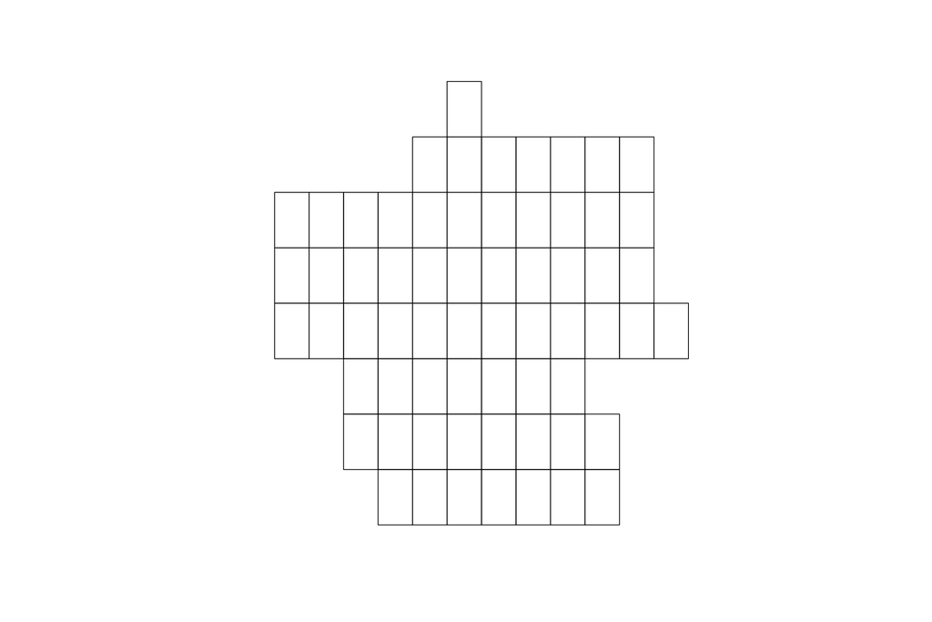

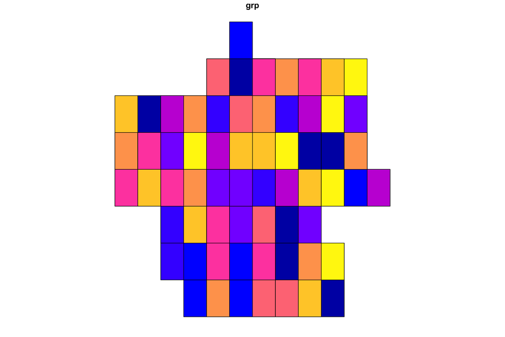

Train using caret, and CAST to quickly create index for it,which applys caret createFolds

```
## Random Forest
##
## 482 samples
##  58 predictor
##
## No pre-processing
## Resampling: Cross-Validated (10 fold)
## Summary of sample sizes: 416, 467, 463, 440, 441, 422, ...
## Resampling results:
##
##   RMSE      Rsquared   MAE
##   7.257982  0.6637754  5.296645
##
## Tuning parameter 'mtry' was held constant at a value of 34
```

#### SP2 customized

- “tr_hp”: close to roads, high population
- “tr_mlp”: close to roads, middle-low population
- “f”: far away from roads

  |  | LA_tr_hp | RF_tr_hp | XGB_tr_hp | LA_tr_lmp | RF_tr_lmp | XGB_tr_lmp | LA_far | RF_far | XGB_far |
  | --- | --- | --- | --- | --- | --- | --- | --- | --- | --- |
  | RMSE | 12.3463322 | 11.5851445 | 11.5400362 | 7.6607589 | 8.82934064 | 8.85368985 | 4.9085948 | 4.4222298 | 3.3558684 |
  | RRMSE | 0.3171534 | 0.2976978 | 0.2963189 | 0.3326383 | 0.38263019 | 0.38430616 | 0.3463206 | 0.3084526 | 0.2307896 |
  | IQR | 18.0893094 | 19.8176291 | 17.0146423 | 10.3495026 | 10.75051885 | 10.53607017 | 4.8570131 | 3.3623746 | 3.5114387 |
  | rIQR | 0.4551165 | 0.5000510 | 0.4259670 | 0.5025240 | 0.52317071 | 0.51551359 | 0.3505233 | 0.2515156 | 0.2594170 |
  | MAE | 10.3207343 | 9.9185413 | 9.6133133 | 6.1181227 | 6.63535351 | 6.57966265 | 4.1901799 | 3.3217097 | 2.4063715 |
  | rMAE | 0.2649816 | 0.2548807 | 0.2469069 | 0.2659236 | 0.28790106 | 0.28596326 | 0.2968251 | 0.2338121 | 0.1673259 |
  | rsq | 0.1007797 | 0.2122494 | 0.2086235 | 0.1915143 | -0.07286583 | -0.07892246 | 0.4793491 | 0.5864176 | 0.7605174 |
  | explained_var | 0.1927631 | 0.2056031 | 0.2020694 | 0.2032250 | 0.06376700 | 0.08228211 | 0.7073388 | 0.6977087 | 0.7767913 |

##### SP3

@params df_type: name of the type considered (e.g. traffic) @params dfall: mergedall @params df_model: merged

|  | LA_tra | RF_tra | XGB_tra | LA_bg | RF_bg | XGB_bg |
| --- | --- | --- | --- | --- | --- | --- |
| RMSE | 11.87460645 | 10.9080192 | 11.1525294 | 5.7181736 | 5.5675144 | 5.7624145 |
| RRMSE | 0.31928306 | 0.2933937 | 0.3000417 | 0.3392273 | 0.3327721 | 0.3454424 |
| IQR | 13.54760783 | 10.7548777 | 10.8112057 | 5.7672679 | 5.4165275 | 4.6863828 |
| rIQR | 0.37014218 | 0.2937480 | 0.2952191 | 0.3568770 | 0.3364051 | 0.2900928 |
| MAE | 9.57026164 | 8.3580370 | 8.6190430 | 4.4823541 | 4.1589777 | 3.8481069 |
| rMAE | 0.25730004 | 0.2247988 | 0.2318595 | 0.2661802 | 0.2481138 | 0.2296338 |
| rsq | 0.04466399 | 0.1907785 | 0.1506530 | 0.4453287 | 0.4708222 | 0.4243200 |
| explained_var | 0.31793636 | 0.4023840 | 0.2824314 | 0.6859951 | 0.6552215 | 0.5117591 |

for a single method (testing purpose)

#### more on random forest

##### 1. test the number of variables needed and pdp

##### 2. uncertainty assessment: quantile rf

1. If using OOB, more variables (> larger than about 20) may always lead to error increase, because each tree is weaker, but when aggregating them the error may be different, therefore here using CV. No big difference between 25-50. May just leave all in as the spatial pattern will be different.

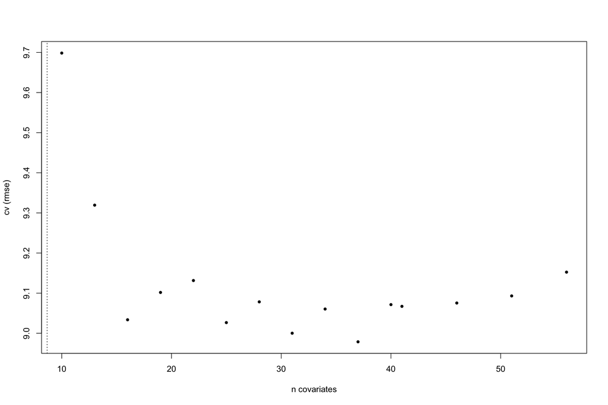

2. As the last step is always the same as linear regression (as we take the mean), the unaggregated predictions (second last layer, or terninal node response value) may be used for uncertainty assessment. Does this applys to all the ML method?

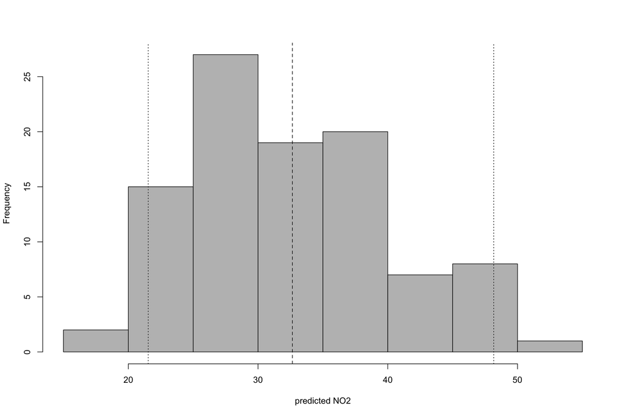

[figure not shown]